# Praca domowa

Jakub Kosterna

# *Techniki Wizualizacji Danych - PD4*

Z pewnością największym problemem owej pracy domowej było znalezienie odpowiedniego wykresu - moi koledzy zdecydowanie sprostali wyzwaniu i ciężko było znaleźć coś, co warto by było poprawić. Pod lupę postanowiłem wziąć wykres Olka, który jak zdecydowanie jest jasny, dostał ode mnie parę fajnych rarytasów wizualnych.

## Wykres Olka:

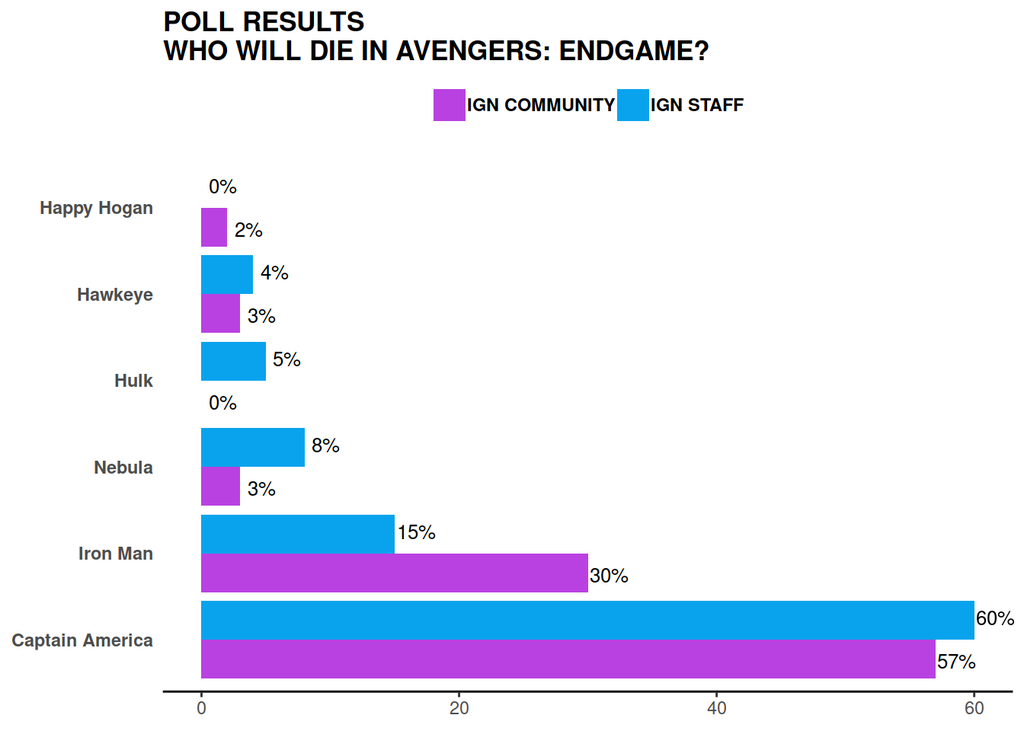

## Wykres Mój:

[figure not shown]

## Dlaczego mój wykres jest lepszy?

1. (Moim zdaniem) najwiekszą zaletą jest zmniejszenie dystansu między nazwami suberbohaterów a słupkami - była to operacja, której dokonałem niemalże od razu, ze względu na niepewność której kolumny dotyczy “Hulk” - mieszanka niebieskiego i purpurowego koloru na zmianę w dodatku w połączeniu z “pustym” słupkiem spowodowały u mnie początkowo niezły dysonans. Z samym *ggplotem* byłoby trochę pierdzielenia z dokładnym dobraniem dystansu w parametrze funkcji (która i tak musiałaby być ręcznie wyszukana i przeterstowana), a potem z próbowaniem różnych wartości aby uzyskać względnie najlepszy efekt - po co strzelać / wyszukiwać binarnie, jeżeli mogę ręcznie bardzo szybko dostosować wielkość?
2. … stwierdziłem jednak, że wciąż to za mało - dlatego każdą parę kolumn oddzieliłem dodatkowymi liniami poziomowymi między etykietami super-bohaterów. Ta metoda doprowadziła już do całkowitej jasności na pierwszy rzut oka które słupki dotyczą której osoby. Nie wiem jak i czy w ogóle taką operację można by wykonać w *R*.
3. Lekko powiększyłem tytuł wykresu, a także minimalnie go wydłużyłem w pionie - jak dla mnie też na plus. Taka nawigacja czcionką z *ggplot*? No, na pewno tutaj łatwiej (o ile można to właściwie zrobić z poziomu pisania kodu w przypadku wydłużenia tytułowego pola tekstowego)!
4. Pierwsza wersja legendy jak dla mnie była nieco szpetna - tak małe odległości między kolorowymi kwadratami i etykietami nie pozwoliły mi nic z tym nie zrobić. I legendę więc powiększyłem, a przede wszystkim wrzuciłem trochę przestrzeni między cztery przed chwilą wspomniane obiekty.
5. Danych nie jest dużo, a szybciej jest przeczytać wykres na pierwszy rzut oka bez obecności tycich literek (niezależnie od warunków biologiczno-fizycznych). Zdecydowałem się więc nieco powiększyć także i informacje o procentach i liczby przy osi x.
6. Ostatnią operacją, której dokonałem, a na pewno nie byłaby możliwa za pomocą *RStudio* (albo osiągnięcie jej byłoby niebywale wymagające): pozwoliłem sobie na dostosowanie wielkości czcionki etykiet osi y do ich długości. Stąd na przykład taki Hulk jest większy od pozostałych, a Captain America ze względu na najdłuższą nazwę i brak miejsca z lewej strony wykresu - najkrótszy. Starałem sie zachować jednak przy tym smak i dążyłem do jak najmniejszej różnicy między dwoma pseudonimami jeden pod drugim.